# Supervised Learning - Foundations Project: ReCell

## Problem Statement

### Business Context

Buying and selling used phones and tablets used to be something that happened on a handful of online marketplace sites. But the used and refurbished device market has grown considerably over the past decade, and a new IDC (International Data Corporation) forecast predicts that the used phone market would be worth \$52.7bn by 2023 with a compound annual growth rate (CAGR) of 13.6% from 2018 to 2023. This growth can be attributed to an uptick in demand for used phones and tablets that offer considerable savings compared with new models.

Refurbished and used devices continue to provide cost-effective alternatives to both consumers and businesses that are looking to save money when purchasing one. There are plenty of other benefits associated with the used device market. Used and refurbished devices can be sold with warranties and can also be insured with proof of purchase. Third-party vendors/platforms, such as Verizon, Amazon, etc., provide attractive offers to customers for refurbished devices. Maximizing the longevity of devices through second-hand trade also reduces their environmental impact and helps in recycling and reducing waste. The impact of the COVID-19 outbreak may further boost this segment as consumers cut back on discretionary spending and buy phones and tablets only for immediate needs.

### Objective

The rising potential of this comparatively under-the-radar market fuels the need for an ML-based solution to develop a dynamic pricing strategy for used and refurbished devices. ReCell, a startup aiming to tap the potential in this market, has hired you as a data scientist. They want you to analyze the data provided and build a linear regression model to predict the price of a used phone/tablet and identify factors that significantly influence it.

### Data Description

The data contains the different attributes of used/refurbished phones and tablets. The data was collected in the year 2021. The detailed data dictionary is given below.

- brand_name: Name of manufacturing brand
- os: OS on which the device runs
- screen_size: Size of the screen in cm
- 4g: Whether 4G is available or not
- 5g: Whether 5G is available or not
- main_camera_mp: Resolution of the rear camera in megapixels
- selfie_camera_mp: Resolution of the front camera in megapixels
- int_memory: Amount of internal memory (ROM) in GB
- ram: Amount of RAM in GB
- battery: Energy capacity of the device battery in mAh
- weight: Weight of the device in grams
- release_year: Year when the device model was released
- days_used: Number of days the used/refurbished device has been used
- normalized_new_price: Normalized price of a new device of the same model in euros
- normalized_used_price: Normalized price of the used/refurbished device in euros

## Importing necessary libraries

```python
#Basic packages
import numpy as np
import pandas as pd

import matplotlib.pyplot as plt
import seaborn as sns

sns.set()

#train test split
from sklearn.model_selection import train_test_split

#linear regression_model
from sklearn.linear_model import LinearRegression

#MAE,MSE,R Squared
from sklearn.metrics import mean_absolute_error, mean_squared_error, r2_score

#Stats model
import statsmodels.api as sm

#VIF computation
from statsmodels.stats.outliers_influence import variance_inflation_factor
```

## Loading the dataset

```python
from google.colab import drive
drive.mount('/content/drive')
df = pd.read_csv('/content/drive/My Drive/Python Course/used_device_data.csv')
df.head()
```

|  | brand_name | os | screen_size | 4g | 5g | main_camera_mp | selfie_camera_mp | int_memory | ram | battery | weight | release_year | days_used | normalized_used_price | normalized_new_price |
| --- | --- | --- | --- | --- | --- | --- | --- | --- | --- | --- | --- | --- | --- | --- | --- |
| 0 | Honor | Android | 14.50 | yes | no | 13.0 | 5.0 | 64.0 | 3.0 | 3020.0 | 146.0 | 2020 | 127 | 4.307572 | 4.715100 |
| 1 | Honor | Android | 17.30 | yes | yes | 13.0 | 16.0 | 128.0 | 8.0 | 4300.0 | 213.0 | 2020 | 325 | 5.162097 | 5.519018 |
| 2 | Honor | Android | 16.69 | yes | yes | 13.0 | 8.0 | 128.0 | 8.0 | 4200.0 | 213.0 | 2020 | 162 | 5.111084 | 5.884631 |
| 3 | Honor | Android | 25.50 | yes | yes | 13.0 | 8.0 | 64.0 | 6.0 | 7250.0 | 480.0 | 2020 | 345 | 5.135387 | 5.630961 |
| 4 | Honor | Android | 15.32 | yes | no | 13.0 | 8.0 | 64.0 | 3.0 | 5000.0 | 185.0 | 2020 | 293 | 4.389995 | 4.947837 |

## Data Overview

- Observations
- Sanity checks

```python
df.head()
#First 5 rows
```

|  | brand_name | os | screen_size | 4g | 5g | main_camera_mp | selfie_camera_mp | int_memory | ram | battery | weight | release_year | days_used | normalized_used_price | normalized_new_price |
| --- | --- | --- | --- | --- | --- | --- | --- | --- | --- | --- | --- | --- | --- | --- | --- |
| 0 | Honor | Android | 14.50 | yes | no | 13.0 | 5.0 | 64.0 | 3.0 | 3020.0 | 146.0 | 2020 | 127 | 4.307572 | 4.715100 |
| 1 | Honor | Android | 17.30 | yes | yes | 13.0 | 16.0 | 128.0 | 8.0 | 4300.0 | 213.0 | 2020 | 325 | 5.162097 | 5.519018 |
| 2 | Honor | Android | 16.69 | yes | yes | 13.0 | 8.0 | 128.0 | 8.0 | 4200.0 | 213.0 | 2020 | 162 | 5.111084 | 5.884631 |
| 3 | Honor | Android | 25.50 | yes | yes | 13.0 | 8.0 | 64.0 | 6.0 | 7250.0 | 480.0 | 2020 | 345 | 5.135387 | 5.630961 |
| 4 | Honor | Android | 15.32 | yes | no | 13.0 | 8.0 | 64.0 | 3.0 | 5000.0 | 185.0 | 2020 | 293 | 4.389995 | 4.947837 |

```python
df.tail()
#Last 5 rows
```

|  | brand_name | os | screen_size | 4g | 5g | main_camera_mp | selfie_camera_mp | int_memory | ram | battery | weight | release_year | days_used | normalized_used_price | normalized_new_price |
| --- | --- | --- | --- | --- | --- | --- | --- | --- | --- | --- | --- | --- | --- | --- | --- |
| 3449 | Asus | Android | 15.34 | yes | no | NaN | 8.0 | 64.0 | 6.0 | 5000.0 | 190.0 | 2019 | 232 | 4.492337 | 6.483872 |
| 3450 | Asus | Android | 15.24 | yes | no | 13.0 | 8.0 | 128.0 | 8.0 | 4000.0 | 200.0 | 2018 | 541 | 5.037732 | 6.251538 |
| 3451 | Alcatel | Android | 15.80 | yes | no | 13.0 | 5.0 | 32.0 | 3.0 | 4000.0 | 165.0 | 2020 | 201 | 4.357350 | 4.528829 |
| 3452 | Alcatel | Android | 15.80 | yes | no | 13.0 | 5.0 | 32.0 | 2.0 | 4000.0 | 160.0 | 2020 | 149 | 4.349762 | 4.624188 |
| 3453 | Alcatel | Android | 12.83 | yes | no | 13.0 | 5.0 | 16.0 | 2.0 | 4000.0 | 168.0 | 2020 | 176 | 4.132122 | 4.279994 |

```python
df.shape
```

```
(3454, 15)
```

There are 3454 rows and 15 columns

```python
df.info()
```

```
<class 'pandas.core.frame.DataFrame'>
RangeIndex: 3454 entries, 0 to 3453
Data columns (total 15 columns):
 #   Column                 Non-Null Count  Dtype
---  ------                 --------------  -----
 0   brand_name             3454 non-null   object
 1   os                     3454 non-null   object
 2   screen_size            3454 non-null   float64
 3   4g                     3454 non-null   object
 4   5g                     3454 non-null   object
 5   main_camera_mp         3275 non-null   float64
 6   selfie_camera_mp       3452 non-null   float64
 7   int_memory             3450 non-null   float64
 8   ram                    3450 non-null   float64
 9   battery                3448 non-null   float64
 10  weight                 3447 non-null   float64
 11  release_year           3454 non-null   int64
 12  days_used              3454 non-null   int64
 13  normalized_used_price  3454 non-null   float64
 14  normalized_new_price   3454 non-null   float64
dtypes: float64(9), int64(2), object(4)
memory usage: 404.9+ KB
```

All columsn except Main_camera_mp, Selfie_camera_mp, Int_Memory, Ram, Battery & Weight columns have complete Not null data values.

```python
df.describe(include='all')
#Stats for all columns detailing count, unique, top, freq, mean, std, min, max, 25%, 50% and 75%
```

|  | brand_name | os | screen_size | 4g | 5g | main_camera_mp | selfie_camera_mp | int_memory | ram | battery | weight | release_year | days_used | normalized_used_price | normalized_new_price |
| --- | --- | --- | --- | --- | --- | --- | --- | --- | --- | --- | --- | --- | --- | --- | --- |
| count | 3454 | 3454 | 3454.000000 | 3454 | 3454 | 3275.000000 | 3452.000000 | 3450.000000 | 3450.000000 | 3448.000000 | 3447.000000 | 3454.000000 | 3454.000000 | 3454.000000 | 3454.000000 |
| unique | 34 | 4 | NaN | 2 | 2 | NaN | NaN | NaN | NaN | NaN | NaN | NaN | NaN | NaN | NaN |
| top | Others | Android | NaN | yes | no | NaN | NaN | NaN | NaN | NaN | NaN | NaN | NaN | NaN | NaN |
| freq | 502 | 3214 | NaN | 2335 | 3302 | NaN | NaN | NaN | NaN | NaN | NaN | NaN | NaN | NaN | NaN |
| mean | NaN | NaN | 13.713115 | NaN | NaN | 9.460208 | 6.554229 | 54.573099 | 4.036122 | 3133.402697 | 182.751871 | 2015.965258 | 674.869716 | 4.364712 | 5.233107 |
| std | NaN | NaN | 3.805280 | NaN | NaN | 4.815461 | 6.970372 | 84.972371 | 1.365105 | 1299.682844 | 88.413228 | 2.298455 | 248.580166 | 0.588914 | 0.683637 |
| min | NaN | NaN | 5.080000 | NaN | NaN | 0.080000 | 0.000000 | 0.010000 | 0.020000 | 500.000000 | 69.000000 | 2013.000000 | 91.000000 | 1.536867 | 2.901422 |
| 25% | NaN | NaN | 12.700000 | NaN | NaN | 5.000000 | 2.000000 | 16.000000 | 4.000000 | 2100.000000 | 142.000000 | 2014.000000 | 533.500000 | 4.033931 | 4.790342 |
| 50% | NaN | NaN | 12.830000 | NaN | NaN | 8.000000 | 5.000000 | 32.000000 | 4.000000 | 3000.000000 | 160.000000 | 2015.500000 | 690.500000 | 4.405133 | 5.245892 |
| 75% | NaN | NaN | 15.340000 | NaN | NaN | 13.000000 | 8.000000 | 64.000000 | 4.000000 | 4000.000000 | 185.000000 | 2018.000000 | 868.750000 | 4.755700 | 5.673718 |
| max | NaN | NaN | 30.710000 | NaN | NaN | 48.000000 | 32.000000 | 1024.000000 | 12.000000 | 9720.000000 | 855.000000 | 2020.000000 | 1094.000000 | 6.619433 | 7.847841 |

```python
df.isnull().sum()
#analysing if there are any null values in the dataset
```

```
brand_name                 0
os                         0
screen_size                0
4g                         0
5g                         0
main_camera_mp           179
selfie_camera_mp           2
int_memory                 4
ram                        4
battery                    6
weight                     7
release_year               0
days_used                  0
normalized_used_price      0
normalized_new_price       0
dtype: int64
```

There are 6 columns with null values (main camera with 179 , selfie camera with 2, int memory & ram with 4, battery with 6 and weight with 7 rows)

```python
df.duplicated().sum()
#Checking if there are no duplicates in the dataset
```

```
0
```

No duplicates exists in this dataset

## Exploratory Data Analysis (EDA)

- EDA is an important part of any project involving data.
- It is important to investigate and understand the data better before building a model with it.
- A few questions have been mentioned below which will help you approach the analysis in the right manner and generate insights from the data.
- A thorough analysis of the data, in addition to the questions mentioned below, should be done.

**Questions**:

1. What does the distribution of normalized used device prices look like?
2. What percentage of the used device market is dominated by Android devices?
3. The amount of RAM is important for the smooth functioning of a device. How does the amount of RAM vary with the brand?
4. A large battery often increases a device's weight, making it feel uncomfortable in the hands. How does the weight vary for phones and tablets offering large batteries (more than 4500 mAh)?
5. Bigger screens are desirable for entertainment purposes as they offer a better viewing experience. How many phones and tablets are available across different brands with a screen size larger than 6 inches?
6. A lot of devices nowadays offer great selfie cameras, allowing us to capture our favorite moments with loved ones. What is the distribution of devices offering greater than 8MP selfie cameras across brands?
7. Which attributes are highly correlated with the normalized price of a used device?

```python
#function to create histogram boxplotting
def histogram_boxplot(data, feature, figsize=(15, 10), kde=False, bins=None):
    """
    Boxplot and histogram combined

    data: dataframe
    feature: dataframe column
    figsize: size of figure (default (15,10))
    kde: whether to show the density curve (default False)
    bins: number of bins for histogram (default None)
    """
    f2, (ax_box2, ax_hist2) = plt.subplots(
        nrows=2,  # Number of rows of the subplot grid= 2
        sharex=True,  # x-axis will be shared among all subplots
        gridspec_kw={"height_ratios": (0.25, 0.75)},
        figsize=figsize,
    )  # creating the 2 subplots
    sns.boxplot(
        data=df, x=feature, ax=ax_box2, showmeans=True, color="violet"
    )  # boxplot will be created and a triangle will indicate the mean value of the column
    sns.histplot(
        data=df, x=feature, kde=kde, ax=ax_hist2, bins=bins
    ) if bins else sns.histplot(
        data=df, x=feature, kde=kde, ax=ax_hist2
    )  # For histogram
    ax_hist2.axvline(
        df[feature].mean(), color="green", linestyle="--"
    )  # Add mean to the histogram
    ax_hist2.axvline(
        df[feature].median(), color="black", linestyle="-"
    )  # Add median to the histogram
```

```python
# function to create labeled barplots
def labeled_barplot(data, feature, perc=False, n=None):
    """
    Barplot with percentage at the top

    data: dataframe
    feature: dataframe column
    perc: whether to display percentages instead of count (default is False)
    n: displays the top n category levels (default is None, i.e., display all levels)
    """

    total = len(data[feature])  # length of the column
    count = df[feature].nunique()
    if n is None:
        plt.figure(figsize=(count + 2, 6))
    else:
        plt.figure(figsize=(n + 2, 6))

    plt.xticks(rotation=90, fontsize=15)
    ax = sns.countplot(
        data=df,
        x=feature,
        palette="Paired",
        order=data[feature].value_counts().index[:n],
    )

    for p in ax.patches:
        if perc == True:
            label = "{:.1f}%".format(
                100 * p.get_height() / total
            )  # percentage of each class of the category
        else:
            label = p.get_height()  # count of each level of the category

        x = p.get_x() + p.get_width() / 2  # width of the plot
        y = p.get_height()  # height of the plot

        ax.annotate(
            label,
            (x, y),
            ha="center",
            va="center",
            size=12,
            xytext=(0, 5),
            textcoords="offset points",
        )  # annotate the percentage

    plt.show()  # show the plot
```

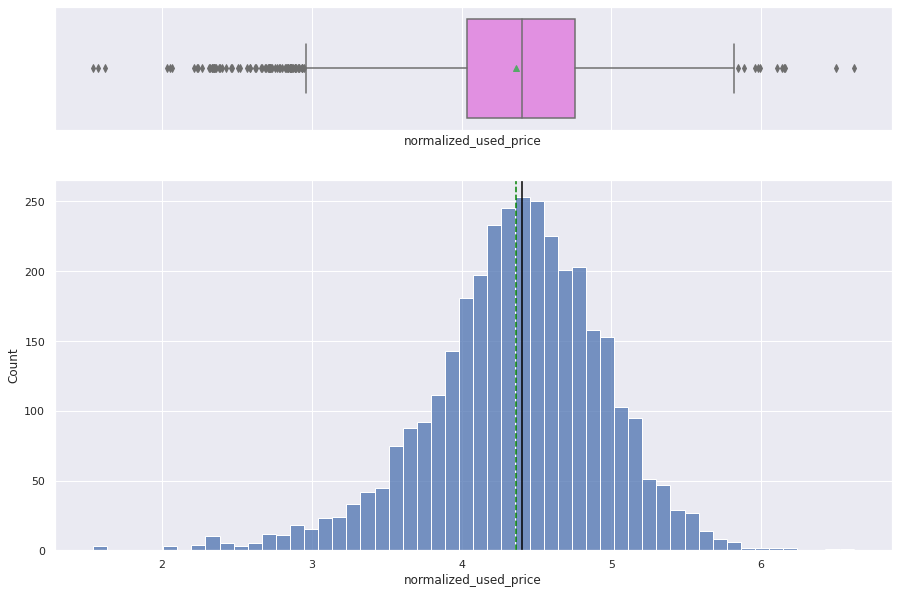

```python
# histogram boxplot for normalized used price attribute
histogram_boxplot(df, "normalized_used_price")
```

1. Several outliers identified in the original dataset
2. Distribution kind of normally distributed

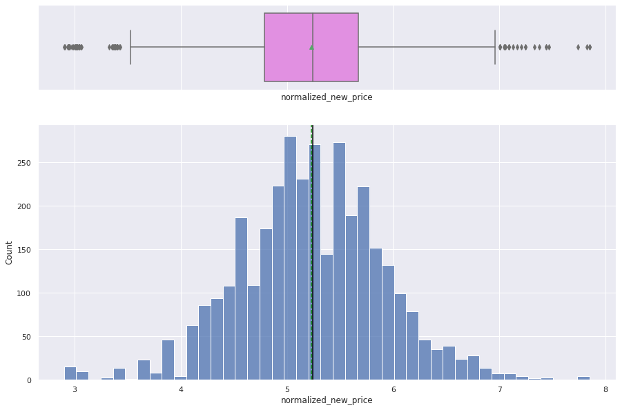

```python
#histogram_boxplot for 'normalized_new_price' attribute
histogram_boxplot(df, 'normalized_new_price')
```

1. Several outliers identified in the original dataset for normalized new price attribute

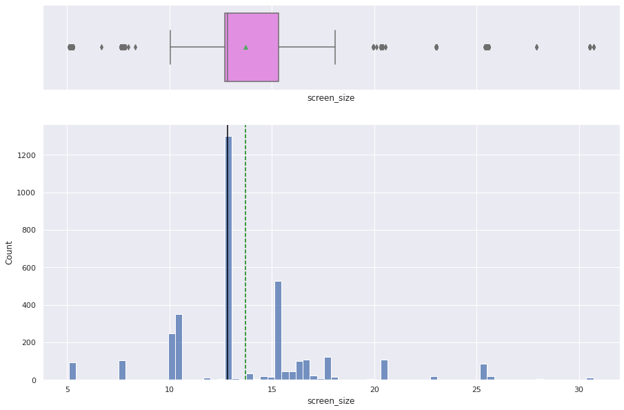

```python
 ## histogram_boxplot for 'screen_size' attribute
histogram_boxplot(df, 'screen_size')
```

1. Several outliers observed in boxplot for screensize attribute
2. Distribution is not normal

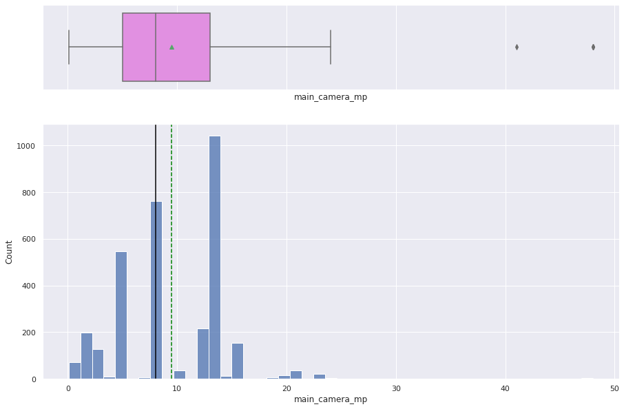

```python
 #histogram_boxplot for 'main_camera_mp'
histogram_boxplot(df, 'main_camera_mp')
```

1. Some outliers spotted in the upper fence alone for main camera mp attribute
2. Distribution is not normal

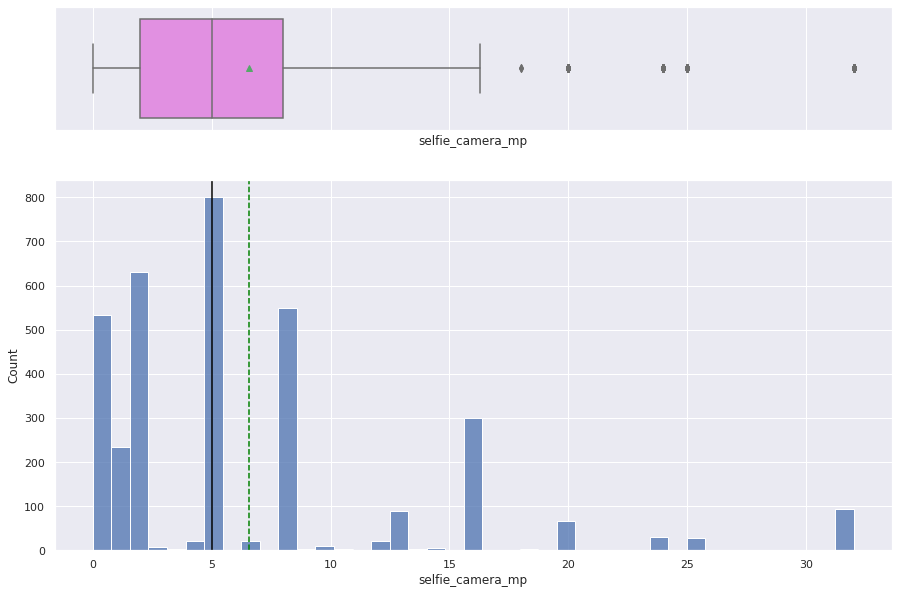

```python
 #histogram_boxplot for 'selfie_camera_mp'
histogram_boxplot(df, 'selfie_camera_mp')
```

1. Some outliers observed in the upper fence for selfie camera mp attribute
2. Distribution is not normal

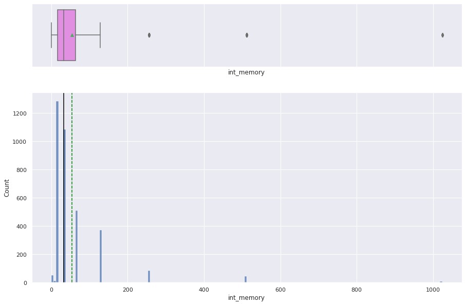

```python
# histogram_boxplot for 'int_memory'
histogram_boxplot(df, 'int_memory')
```

1. Some outliers observed in the upper fence for int memory attribute
2. Distribution is not normal

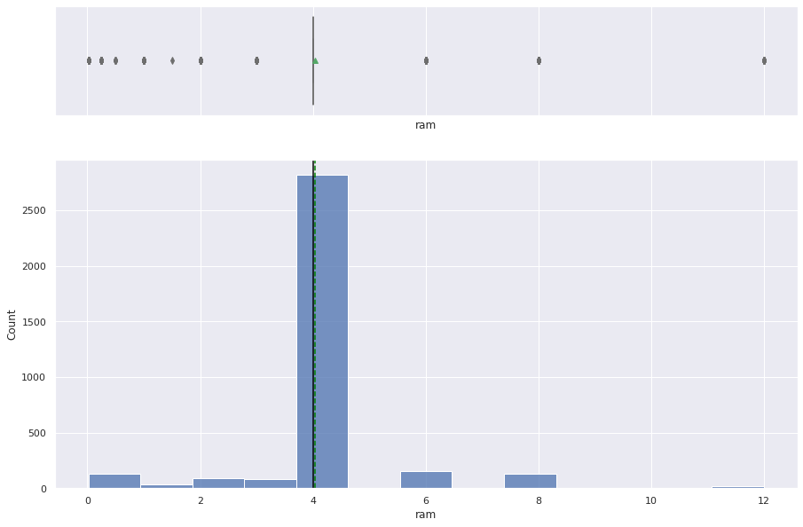

```python
# histogram_boxplot for 'ram'
histogram_boxplot(df,'ram')
```

1. Outliers exists in both lower and upper fence for ram attribute
2. Distribution is not normal

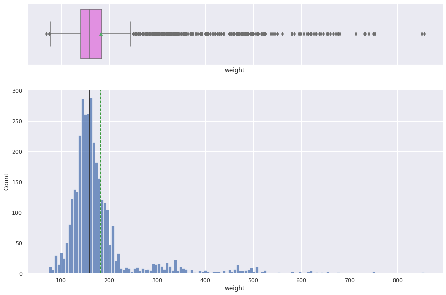

```python
# histogram_boxplot for 'weight'
histogram_boxplot(df, 'weight')
```

1. Several outliers exists in weight attribute
2. Distribution is not normal and is right skewed

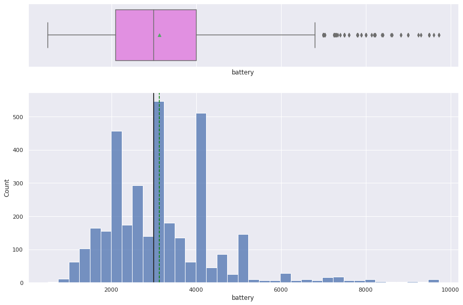

```python
# histogram_boxplot for 'battery'
histogram_boxplot(df, 'battery')
```

1. Outliers exists in the upper fence for battery attribute
2. Distribution is not normal and is right skewed

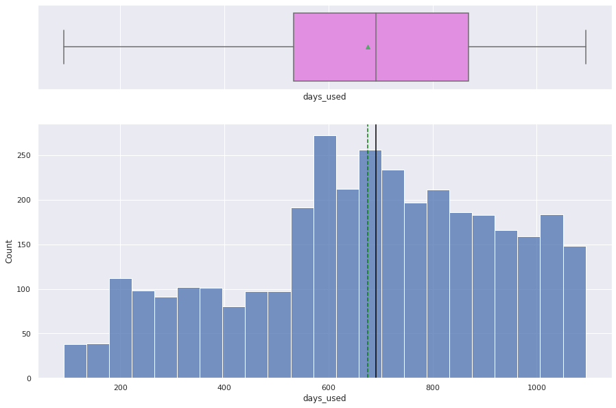

```python
# histogram_boxplot for 'days_used'
histogram_boxplot(df, 'days_used')  ## Complete the code to create histogram_boxplot for 'main_camera_mp'
```

1. No outliers exists for days used attribute
2. Distribution is not normal and is left skewed

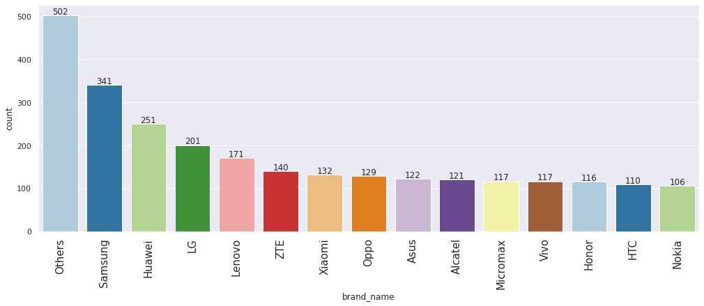

```python
# labelled plot for 'brand name'
labeled_barplot(df, "brand_name", perc=False, n=15)
```

1. Analysis shows unfamiliar brand (Others) have more users compared to familiar brands like Samsung Apple etc
2. Samsung tops the 2nd in the list with 341 count followed by Huawai with 251 and LG with 201

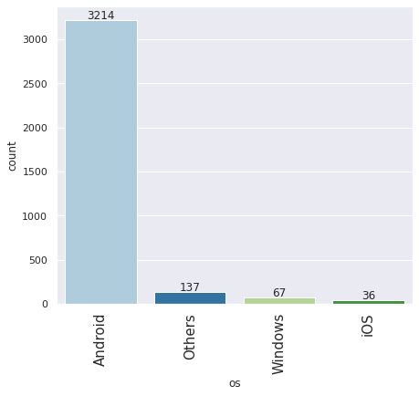

```python
# labelled plot for 'os'
labeled_barplot(df, "os", perc=False, n=5)
```

1. Android OS tops the list with 3214 count compared to Others / Windows and ios
2. IOS has the least users with just 36 count

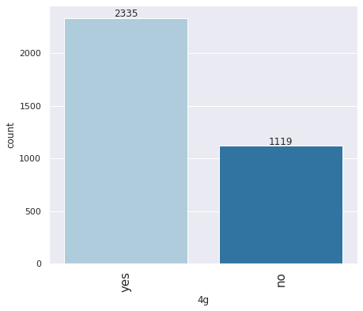

```python
# labelled plot for '4g'
labeled_barplot(df, "4g", perc=False, n=5)
```

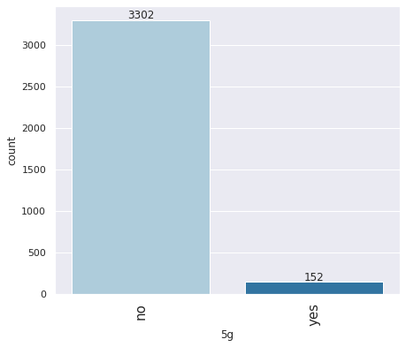

```python
# labelled plot for '5g'
labeled_barplot(df, "5g", perc=False, n=5)
```

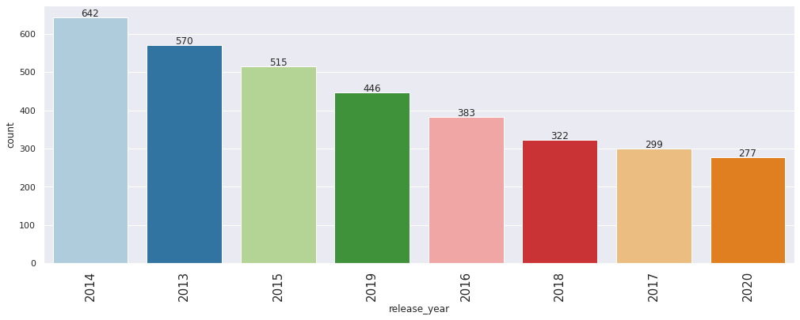

```python
# labelled plot for 'release yeare'
labeled_barplot(df, "release_year", perc=False, n=15)
```

1. 2014 year had more sales (642 count) compared to 2020
2. 2020 year has the least sales with 277
3. 2013 tops the 2nd place with 570 count

# **Bivariate Analysis**

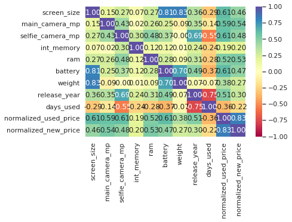

```python
#Correlation check on numerical columns

a = df.describe().columns.tolist() #  creating a list of numerical columns
sns.heatmap(df[a].corr(), annot=True, vmin=-1, vmax=1, fmt=".2f", cmap="Spectral") # perform heatmap on newly created variable with numerical columns
plt.show()
```

1. heat map correlation is higher for screensize & weight with 0.83
2. corr is higher even for screensize & battery with 0.81

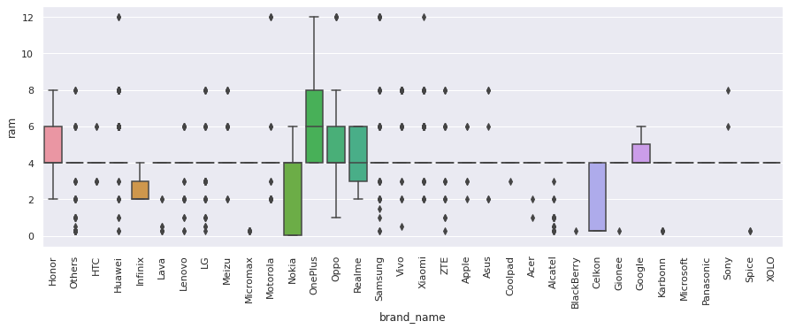

```python
#boxplot on ram vs brand name analysis

plt.figure(figsize=(15, 5))
sns.boxplot(data=df, x="brand_name", y="ram") # boxplot analysis on brand name and ram
plt.xticks(rotation=90)
plt.show()
```

1. Average Ram for One Plus is 6
2. Several outliers exists for brands like HTS, Huawei, LG, Samsung and Apple
3. No outliers exists for Honor, Infinix, Nokiam OnePlus, Google, Microsoft
4. Average Ram for all brands is around 4

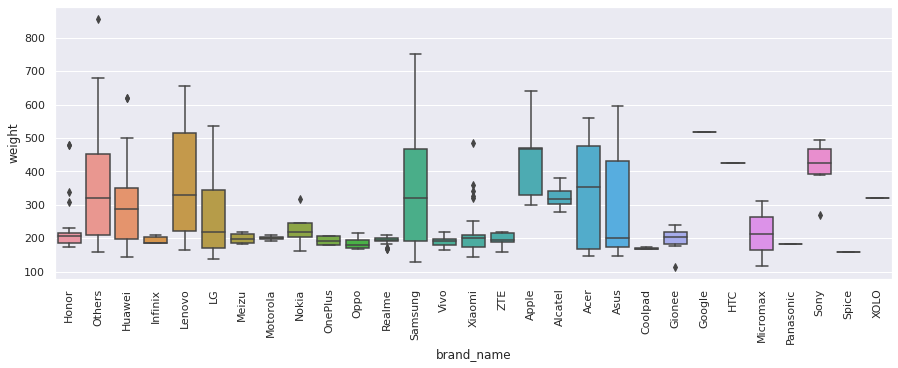

```python
#battery vs weight analysis

#filter battery > 4000 and create a new dataframe
df_battery = df[df.battery > 4000]
df_battery.shape
plt.figure(figsize=(15, 5))
sns.boxplot(data=df_battery, x='brand_name', y ='weight') #sns boxplot for brand name and weight based on filtered battery dataset
plt.xticks(rotation=90)
plt.show()
```

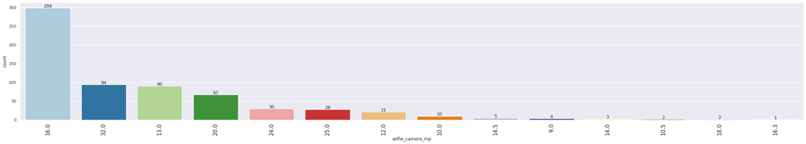

```python
#selfie camera labelled bar plot analysis

#filter selfie camera > 8 and create a new dataframe
df_front_camera = df[df.selfie_camera_mp > 8]
df_front_camera.shape
labeled_barplot(df_front_camera, 'selfie_camera_mp') #perform a labeled barplot for selfie camera based on the filtered dataset
```

1. Selfie camera with 16 MP bags the top place with 298 count
2. Selfie camera with 32 MP bags the 2nd place with 94 count
3. Selfie camera with 13 MP bags the 3rd place with 90 count

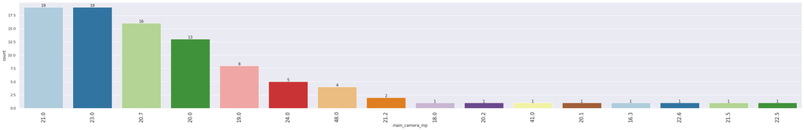

```python
#main camera labelled bar plot analysis

#filter main camera > 8 and create a new dataframe
plt.figure(figsize=(10, 5))
df_main_camera = df[df.main_camera_mp > 16]
df_main_camera.shape
labeled_barplot(df_main_camera, 'main_camera_mp') #perform a labeled barplot for main camera based on the filtered dataset
```

1. Main Camera (Rear) with 21 & 23 MP holds the top place with 19 count
2. Main Camera (Rear) with 20.7 MP holds the 2nd place with 16 count

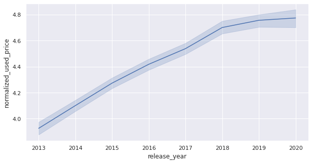

```python
#Line plot analysis on used price vs year released

plt.figure(figsize=(10, 5))
sns.lineplot(data = df, x='release_year', y='normalized_used_price')
plt.show()
```

1. Normalized used price tends to increase for phones released recently compared to those released earlier

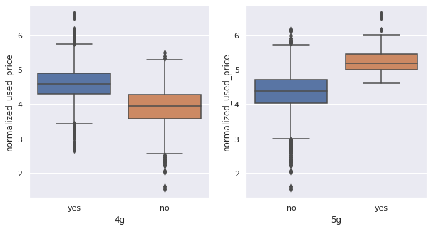

```python
#Box plot analysis on Used Price and New Price

plt.figure(figsize=(10, 5))
plt.subplot(121)
sns.boxplot(data=df, x="4g", y="normalized_used_price")
plt.subplot(122)
sns.boxplot(data=df, x="5g", y="normalized_used_price")

plt.show()
```

1. Normalized used price for 4g phones have a higher mean of 4.5 compared to non 4g phones with a mean of less than 4
2. Normalized used price for 5g phones have a higher mean of approx 5.25 compared to non 5g phones with a mean of approx 4.5

## Data Preprocessing

- Missing value treatment
- Feature engineering (if needed)
- Outlier detection and treatment (if needed)
- Preparing data for modeling
- Any other preprocessing steps (if needed)

# **Missing value treatment**

```python
# checking for missing values
df.isnull().sum()
```

```
brand_name                 0
os                         0
screen_size                0
4g                         0
5g                         0
main_camera_mp           179
selfie_camera_mp           2
int_memory                 4
ram                        4
battery                    6
weight                     7
release_year               0
days_used                  0
normalized_used_price      0
normalized_new_price       0
dtype: int64
```

1. there are 6 columns (main camera, selfie camera, int memory, ram, battery and weight) which have null values observed that needs correction as part of preprocessing
2. main camera has 179 null values, selfie with 2, int memory & ram with 4 , battery with 6 and weight with 7

```python
#create a copy of the original dataset before attempting to make modifications / correct it as part of pre processing
df2 = df.copy()
df2.shape
```

```
(3454, 15)
```

we see rows and columns count of original dataframe (df) matches with copied dataframe (df2), so we have successfully created a copy of the original dataframe

```python
#handle missing values based on brand name and release year

cols_missing = [
    "main_camera_mp",
    "selfie_camera_mp",
    "int_memory",
    "ram",
    "battery",
    "weight",
]

for col in cols_missing:
    df2[col] = df2[col].fillna(
        value=df2.groupby(['release_year', 'brand_name'])[col].transform("median")
    )

# checking for missing values
df2.isnull().sum()
```

```
brand_name                 0
os                         0
screen_size                0
4g                         0
5g                         0
main_camera_mp           179
selfie_camera_mp           2
int_memory                 0
ram                        0
battery                    6
weight                     7
release_year               0
days_used                  0
normalized_used_price      0
normalized_new_price       0
dtype: int64
```

1. It appears that still main camera, selfie camera , battery and weight have null data based on release yr and brand name combination

```python
#handle missing values based on brand name alone

cols_missing = [
    "main_camera_mp",
    "selfie_camera_mp",
     "battery",
    "weight",
]

for col in cols_missing:
    df2[col] = df2[col].fillna(
        value=df2.groupby(['brand_name'])[col].transform("median")
    )

# checking for missing values
df2.isnull().sum()
```

```
brand_name                0
os                        0
screen_size               0
4g                        0
5g                        0
main_camera_mp           10
selfie_camera_mp          0
int_memory                0
ram                       0
battery                   0
weight                    0
release_year              0
days_used                 0
normalized_used_price     0
normalized_new_price      0
dtype: int64
```

1. It appears that still main camera has null values even after using just brand name filtering

```python
#handle missing values based on direct median on the same column 'main_camera_mp'
df2['main_camera_mp'] = df2['main_camera_mp'].fillna(df2['main_camera_mp'].median())
df2.isnull().sum()
```

```
brand_name               0
os                       0
screen_size              0
4g                       0
5g                       0
main_camera_mp           0
selfie_camera_mp         0
int_memory               0
ram                      0
battery                  0
weight                   0
release_year             0
days_used                0
normalized_used_price    0
normalized_new_price     0
dtype: int64
```

1. after imputing median directly on the main camera attribute, there are no more null values in the main camera. We are now good with preprocessing step to continue forward

# **Feature Engineering**

```python
#create a new derived column 'years_since_release' using 'release_year' column and dropping the same. Max release year shows as 2020, so baseline can be done as 2021
df2["years_since_release"] = 2021 - df2["release_year"]
df2.drop("release_year", axis=1, inplace=True)
df2["years_since_release"].describe().T
```

```
count    3454.000000
mean        5.034742
std         2.298455
min         1.000000
25%         3.000000
50%         5.500000
75%         7.000000
max         8.000000
Name: years_since_release, dtype: float64
```

```python
df2.describe().T
df2.head()
```

|  | brand_name | os | screen_size | 4g | 5g | main_camera_mp | selfie_camera_mp | int_memory | ram | battery | weight | days_used | normalized_used_price | normalized_new_price | years_since_release |
| --- | --- | --- | --- | --- | --- | --- | --- | --- | --- | --- | --- | --- | --- | --- | --- |
| 0 | Honor | Android | 14.50 | yes | no | 13.0 | 5.0 | 64.0 | 3.0 | 3020.0 | 146.0 | 127 | 4.307572 | 4.715100 | 1 |
| 1 | Honor | Android | 17.30 | yes | yes | 13.0 | 16.0 | 128.0 | 8.0 | 4300.0 | 213.0 | 325 | 5.162097 | 5.519018 | 1 |
| 2 | Honor | Android | 16.69 | yes | yes | 13.0 | 8.0 | 128.0 | 8.0 | 4200.0 | 213.0 | 162 | 5.111084 | 5.884631 | 1 |
| 3 | Honor | Android | 25.50 | yes | yes | 13.0 | 8.0 | 64.0 | 6.0 | 7250.0 | 480.0 | 345 | 5.135387 | 5.630961 | 1 |
| 4 | Honor | Android | 15.32 | yes | no | 13.0 | 8.0 | 64.0 | 3.0 | 5000.0 | 185.0 | 293 | 4.389995 | 4.947837 | 1 |

# **Outlier detection using boxplot**

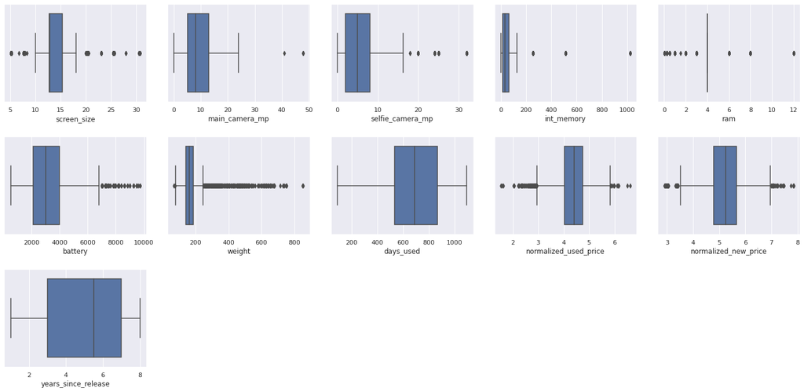

```python
# outlier detection using boxplot
outliers = df2.describe().columns.tolist()
outliers
plt.figure(figsize=(20, 10))

for i, j in enumerate(outliers):
    plt.subplot(3, 5, i + 1)
    sns.boxplot(data=df2, x=j)
    plt.tight_layout(pad=2)

plt.show()
```

1. No outliers spotted in 'days used' and derived column 'years since release'
2. Outliers spotted in 'main camera', 'selfie camera', 'int memory', 'ram', 'battery', 'weight', 'normalized used and new prices'
3. average battery is around 3000
4. average weight is around 180
5. average days used is around 680
6. average ram is around 4

Upon analysis of the above outliers, these outliers seems to be proper data values and not true outliers. Hers is the analysis update on outliers 🇰

1. Main camera max mp in the dataset is 48mp (per industry standards, don’t think it’s an outlier as there are way more higher mp available )
2. Selfie camera max mp in the dataset is 32 mp(per industry standards, don’t think it’s an outlier, as there are way more higher mp available)
3. Int memory max is 1TB in dataset ( per industry standards there are 1TB capacity available, so don’t think it’s an outlier )
4. Max Ram size in the dataset is 12 (per industry standards, it’s not an outlier )
5. Weight max is 855 grams in the dataset ( again not an outlier per industry standards)
6. Battery max is 9720 in the dataset ( I see there are high powered tablets in the industry as well closer to 10000 mah) now let me know if you think these can be treated as outliers or still think these are valid values

## EDA

- It is a good idea to explore the data once again after manipulating it.

**Below command is just to see high level stats between original dataframe (df) and preprocessed dataframe (df2)**

```python
#Original dataframe before / without  data preprocessing
df.describe().T
```

|  | count | mean | std | min | 25% | 50% | 75% | max |
| --- | --- | --- | --- | --- | --- | --- | --- | --- |
| screen_size | 3454.0 | 13.713115 | 3.805280 | 5.080000 | 12.700000 | 12.830000 | 15.340000 | 30.710000 |
| main_camera_mp | 3275.0 | 9.460208 | 4.815461 | 0.080000 | 5.000000 | 8.000000 | 13.000000 | 48.000000 |
| selfie_camera_mp | 3452.0 | 6.554229 | 6.970372 | 0.000000 | 2.000000 | 5.000000 | 8.000000 | 32.000000 |
| int_memory | 3450.0 | 54.573099 | 84.972371 | 0.010000 | 16.000000 | 32.000000 | 64.000000 | 1024.000000 |
| ram | 3450.0 | 4.036122 | 1.365105 | 0.020000 | 4.000000 | 4.000000 | 4.000000 | 12.000000 |
| battery | 3448.0 | 3133.402697 | 1299.682844 | 500.000000 | 2100.000000 | 3000.000000 | 4000.000000 | 9720.000000 |
| weight | 3447.0 | 182.751871 | 88.413228 | 69.000000 | 142.000000 | 160.000000 | 185.000000 | 855.000000 |
| release_year | 3454.0 | 2015.965258 | 2.298455 | 2013.000000 | 2014.000000 | 2015.500000 | 2018.000000 | 2020.000000 |
| days_used | 3454.0 | 674.869716 | 248.580166 | 91.000000 | 533.500000 | 690.500000 | 868.750000 | 1094.000000 |
| normalized_used_price | 3454.0 | 4.364712 | 0.588914 | 1.536867 | 4.033931 | 4.405133 | 4.755700 | 6.619433 |
| normalized_new_price | 3454.0 | 5.233107 | 0.683637 | 2.901422 | 4.790342 | 5.245892 | 5.673718 | 7.847841 |

```python
#New dataframe After data preprocessing
df2.describe().T
```

|  | count | mean | std | min | 25% | 50% | 75% | max |
| --- | --- | --- | --- | --- | --- | --- | --- | --- |
| screen_size | 3454.0 | 13.713115 | 3.805280 | 5.080000 | 12.700000 | 12.830000 | 15.340000 | 30.710000 |
| main_camera_mp | 3454.0 | 9.617597 | 4.749438 | 0.080000 | 5.000000 | 8.000000 | 13.000000 | 48.000000 |
| selfie_camera_mp | 3454.0 | 6.555067 | 6.968440 | 0.000000 | 2.000000 | 5.000000 | 8.000000 | 32.000000 |
| int_memory | 3454.0 | 54.528474 | 84.934991 | 0.010000 | 16.000000 | 32.000000 | 64.000000 | 1024.000000 |
| ram | 3454.0 | 4.032620 | 1.368598 | 0.020000 | 4.000000 | 4.000000 | 4.000000 | 12.000000 |
| battery | 3454.0 | 3132.577446 | 1298.884193 | 500.000000 | 2100.000000 | 3000.000000 | 4000.000000 | 9720.000000 |
| weight | 3454.0 | 182.636856 | 88.360445 | 69.000000 | 142.000000 | 160.000000 | 185.000000 | 855.000000 |
| days_used | 3454.0 | 674.869716 | 248.580166 | 91.000000 | 533.500000 | 690.500000 | 868.750000 | 1094.000000 |
| normalized_used_price | 3454.0 | 4.364712 | 0.588914 | 1.536867 | 4.033931 | 4.405133 | 4.755700 | 6.619433 |
| normalized_new_price | 3454.0 | 5.233107 | 0.683637 | 2.901422 | 4.790342 | 5.245892 | 5.673718 | 7.847841 |
| years_since_release | 3454.0 | 5.034742 | 2.298455 | 1.000000 | 3.000000 | 5.500000 | 7.000000 | 8.000000 |

**Observations on Stats comparison b/w Pre and Post Data Processing clean up:**

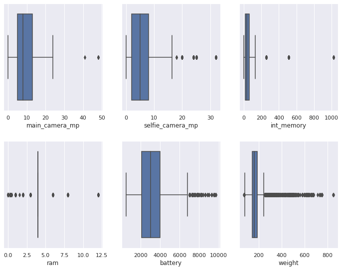

```python
#Creating a loop to show box plots for columns which were cleansed as part of data preprocessing step (i.e fixing null values for the 6 columns)
data_after_preprocessing = ['main_camera_mp', 'selfie_camera_mp', 'int_memory', 'ram', 'battery', 'weight']
plt.figure(figsize=(10, 8))

for i, j in enumerate(data_after_preprocessing):
    plt.subplot(2, 3, i + 1)
    sns.boxplot(data=df2[data_after_preprocessing], x=j)
    plt.tight_layout(pad=2)

plt.show()
```

**Observations :** Above plots still shows outliers, because we didn't clean the outliers as these outliers are proper values as detailed earlier. This plotting is just to see how the data looks like after addressing data preprocessing process which helped in fixing the null values.

# **Data Preparation for Model Building**

```python
## Define the dependent and independent variables on the preprocessed dataframe df2
X = df2.drop(["normalized_used_price"], axis=1) # dependent variables minus predicted variable
y = df2['normalized_used_price'] # predicted variable

print(X.head())
print("*"*100)
print(y.head())
```

```
  brand_name       os  screen_size   4g   5g  main_camera_mp  \
0      Honor  Android        14.50  yes   no            13.0
1      Honor  Android        17.30  yes  yes            13.0
2      Honor  Android        16.69  yes  yes            13.0
3      Honor  Android        25.50  yes  yes            13.0
4      Honor  Android        15.32  yes   no            13.0

   selfie_camera_mp  int_memory  ram  battery  weight  days_used  \
0               5.0        64.0  3.0   3020.0   146.0        127
1              16.0       128.0  8.0   4300.0   213.0        325
2               8.0       128.0  8.0   4200.0   213.0        162
3               8.0        64.0  6.0   7250.0   480.0        345
4               8.0        64.0  3.0   5000.0   185.0        293

   normalized_new_price  years_since_release
0              4.715100                    1
1              5.519018                    1
2              5.884631                    1
3              5.630961                    1
4              4.947837                    1
0    4.307572
1    5.162097
2    5.111084
3    5.135387
4    4.389995
Name: normalized_used_price, dtype: float64
```

```python
# let's add the intercept to data
X = sm.add_constant(X)
```

```python
# applying get dummies method on the categorical fields to create numerical data
X = pd.get_dummies(
    X,
    columns=X.select_dtypes(include=["object", "category"]).columns.tolist(),
    drop_first=True,
)
X.head()
```

|  | const | screen_size | main_camera_mp | selfie_camera_mp | int_memory | ram | battery | weight | days_used | normalized_new_price | ... | brand_name_Spice | brand_name_Vivo | brand_name_XOLO | brand_name_Xiaomi | brand_name_ZTE | os_Others | os_Windows | os_iOS | 4g_yes | 5g_yes |
| --- | --- | --- | --- | --- | --- | --- | --- | --- | --- | --- | --- | --- | --- | --- | --- | --- | --- | --- | --- | --- | --- |
| 0 | 1.0 | 14.50 | 13.0 | 5.0 | 64.0 | 3.0 | 3020.0 | 146.0 | 127 | 4.715100 | ... | 0 | 0 | 0 | 0 | 0 | 0 | 0 | 0 | 1 | 0 |
| 1 | 1.0 | 17.30 | 13.0 | 16.0 | 128.0 | 8.0 | 4300.0 | 213.0 | 325 | 5.519018 | ... | 0 | 0 | 0 | 0 | 0 | 0 | 0 | 0 | 1 | 1 |
| 2 | 1.0 | 16.69 | 13.0 | 8.0 | 128.0 | 8.0 | 4200.0 | 213.0 | 162 | 5.884631 | ... | 0 | 0 | 0 | 0 | 0 | 0 | 0 | 0 | 1 | 1 |
| 3 | 1.0 | 25.50 | 13.0 | 8.0 | 64.0 | 6.0 | 7250.0 | 480.0 | 345 | 5.630961 | ... | 0 | 0 | 0 | 0 | 0 | 0 | 0 | 0 | 1 | 1 |
| 4 | 1.0 | 15.32 | 13.0 | 8.0 | 64.0 | 3.0 | 5000.0 | 185.0 | 293 | 4.947837 | ... | 0 | 0 | 0 | 0 | 0 | 0 | 0 | 0 | 1 | 0 |

5 rows × 49 columns

```python
#creating variables x_train, x_test, y_train, y_test using train test split function with 70 : 30 ratio split
x_train, x_test, y_train, y_test = train_test_split(X, y, test_size=0.3, random_state=1)
```

```python
print("Number of rows in train data =", x_train.shape[0])
print("Number of rows in test data =", x_test.shape[0])
```

```
Number of rows in train data = 2417
Number of rows in test data = 1037
```

1. There are 2417 training data & 1037 test data

# Model Building for Linear Regression

```python
# using the fit method on training attributes (x train and y train) and printing the summary to see r squared , adjusted r squared values along with p values for all attributes
olsmodel = sm.OLS(y_train, x_train).fit()
print(olsmodel.summary())
```

```
                              OLS Regression Results
=================================================================================
Dep. Variable:     normalized_used_price   R-squared:                       0.845
Model:                               OLS   Adj. R-squared:                  0.842
Method:                    Least Squares   F-statistic:                     268.7
Date:                   Wed, 10 Aug 2022   Prob (F-statistic):               0.00
Time:                           00:11:51   Log-Likelihood:                 123.85
No. Observations:                   2417   AIC:                            -149.7
Df Residuals:                       2368   BIC:                             134.0
Df Model:                             48
Covariance Type:               nonrobust
=========================================================================================
                            coef    std err          t      P>|t|      [0.025      0.975]
-----------------------------------------------------------------------------------------
const                     1.3156      0.071     18.454      0.000       1.176       1.455
screen_size               0.0244      0.003      7.163      0.000       0.018       0.031
main_camera_mp            0.0208      0.002     13.848      0.000       0.018       0.024
selfie_camera_mp          0.0135      0.001     11.997      0.000       0.011       0.016
int_memory                0.0001   6.97e-05      1.651      0.099   -2.16e-05       0.000
ram                       0.0230      0.005      4.451      0.000       0.013       0.033
battery               -1.689e-05   7.27e-06     -2.321      0.020   -3.12e-05   -2.62e-06
weight                    0.0010      0.000      7.480      0.000       0.001       0.001
days_used              4.216e-05   3.09e-05      1.366      0.172   -1.84e-05       0.000
normalized_new_price      0.4311      0.012     35.147      0.000       0.407       0.455
years_since_release      -0.0237      0.005     -5.193      0.000      -0.033      -0.015
brand_name_Alcatel        0.0154      0.048      0.323      0.747      -0.078       0.109
brand_name_Apple         -0.0038      0.147     -0.026      0.980      -0.292       0.285
brand_name_Asus           0.0151      0.048      0.314      0.753      -0.079       0.109
brand_name_BlackBerry    -0.0300      0.070     -0.427      0.669      -0.168       0.108
brand_name_Celkon        -0.0468      0.066     -0.707      0.480      -0.177       0.083
brand_name_Coolpad        0.0209      0.073      0.287      0.774      -0.122       0.164
brand_name_Gionee         0.0448      0.058      0.775      0.438      -0.068       0.158
brand_name_Google        -0.0326      0.085     -0.385      0.700      -0.199       0.133
brand_name_HTC           -0.0130      0.048     -0.270      0.787      -0.108       0.081
brand_name_Honor          0.0317      0.049      0.644      0.520      -0.065       0.128
brand_name_Huawei        -0.0020      0.044     -0.046      0.964      -0.089       0.085
brand_name_Infinix        0.1633      0.093      1.752      0.080      -0.019       0.346
brand_name_Karbonn        0.0943      0.067      1.405      0.160      -0.037       0.226
brand_name_LG            -0.0132      0.045     -0.291      0.771      -0.102       0.076
brand_name_Lava           0.0332      0.062      0.533      0.594      -0.089       0.155
```

[output cut: 19 more lines]

```
os_Windows               -0.0207      0.045     -0.459      0.646      -0.109       0.068
os_iOS                   -0.0663      0.146     -0.453      0.651      -0.354       0.221
4g_yes                    0.0528      0.016      3.326      0.001       0.022       0.084
5g_yes                   -0.0714      0.031     -2.268      0.023      -0.133      -0.010
==============================================================================
Omnibus:                      223.612   Durbin-Watson:                   1.910
Prob(Omnibus):                  0.000   Jarque-Bera (JB):              422.275
Skew:                          -0.620   Prob(JB):                     2.01e-92
Kurtosis:                       4.630   Cond. No.                     1.78e+05
==============================================================================

Warnings:
[1] Standard Errors assume that the covariance matrix of the errors is correctly specified.
[2] The condition number is large, 1.78e+05. This might indicate that there are
strong multicollinearity or other numerical problems.
```

**Interpretation of Results:**

## Model Performance Check

```python
# function to compute adjusted R-squared
def adj_r2_score(predictors, targets, predictions):
    r2 = r2_score(targets, predictions)
    n = predictors.shape[0]
    k = predictors.shape[1]
    return 1 - ((1 - r2) * (n - 1) / (n - k - 1))


# function to compute MAPE
def mape_score(targets, predictions):
    return np.mean(np.abs(targets - predictions) / targets) * 100


# function to compute different metrics to check performance of a regression model
def model_performance_regression(model, predictors, target):
    """
    Function to compute different metrics to check regression model performance

    model: regressor
    predictors: independent variables
    target: dependent variable
    """

    # predicting using the independent variables
    pred = model.predict(predictors)

    r2 = r2_score(target, pred)  # to compute R-squared
    adjr2 = adj_r2_score(predictors, target, pred)  # to compute adjusted R-squared
    rmse = np.sqrt(mean_squared_error(target, pred))  # to compute RMSE
    mae = mean_absolute_error(target, pred)  # to compute MAE
    mape = mape_score(target, pred)  # to compute MAPE

    # creating a dataframe of metrics
    df_perf = pd.DataFrame(
        {
            "RMSE": rmse,
            "MAE": mae,
            "R-squared": r2,
            "Adj. R-squared": adjr2,
            "MAPE": mape,
        },
        index=[0],
    )

    return df_perf
```

```python
# checking model performance on train set (seen 70% data)
print("Training Performance\n")
olsmodel_train_perf = model_performance_regression(olsmodel, x_train, y_train)
olsmodel_train_perf
```

```
Training Performance
```

|  | RMSE | MAE | R-squared | Adj. R-squared | MAPE |
| --- | --- | --- | --- | --- | --- |
| 0 | 0.229884 | 0.180326 | 0.844886 | 0.841675 | 4.326841 |

**Observations**

## Checking Linear Regression Assumptions

- In order to make statistical inferences from a linear regression model, it is important to ensure that the assumptions of linear regression are satisfied.

We will be checking the following Linear Regression assumptions:

No Multicollinearity

Linearity of variables

Independence of error terms

Normality of error terms

No Heteroscedasticity

**1. Testing for Multi Collinearity**

Variance Inflation Factor (VIF): Variance inflation factors measure the inflation in the variances of the regression parameter estimates due to collinearities that exist among the predictors. It is a measure of how much the variance of the estimated regression coefficient βk is "inflated" by the existence of correlation among the predictor variables in the model.

If VIF is 1, then there is no correlation among the k th predictor and the remaining predictor variables, and hence, the variance of βk is not inflated at all. General Rule of thumb:

If VIF is between 1 and 5, then there is low multicollinearity. If VIF is between 5 and 10, we say there is moderate multicollinearity. If VIF is exceeding 10, it shows signs of high multicollinearity.

```python
# importing VIF from stats.outliers_influence
from statsmodels.stats.outliers_influence import variance_inflation_factor

# function for higher vif predictions
def checking_vif(predictors):
    vif = pd.DataFrame()
    vif["feature"] = predictors.columns

    # calculating VIF for each feature
    vif["VIF"] = [
        variance_inflation_factor(predictors.values, i)
        for i in range(len(predictors.columns))
    ]
    return vif
```

```python
checking_vif(x_train) # applying VIF on the x train variable
```

|  | feature | VIF |
| --- | --- | --- |
| 0 | const | 227.744081 |
| 1 | screen_size | 7.677290 |
| 2 | main_camera_mp | 2.285051 |
| 3 | selfie_camera_mp | 2.812473 |
| 4 | int_memory | 1.364152 |
| 5 | ram | 2.282352 |
| 6 | battery | 4.081780 |
| 7 | weight | 6.396749 |
| 8 | days_used | 2.660269 |
| 9 | normalized_new_price | 3.119430 |
| 10 | years_since_release | 4.899007 |
| 11 | brand_name_Alcatel | 3.405693 |
| 12 | brand_name_Apple | 13.057668 |
| 13 | brand_name_Asus | 3.332038 |
| 14 | brand_name_BlackBerry | 1.632378 |
| 15 | brand_name_Celkon | 1.774721 |
| 16 | brand_name_Coolpad | 1.468006 |
| 17 | brand_name_Gionee | 1.951272 |
| 18 | brand_name_Google | 1.321778 |
| 19 | brand_name_HTC | 3.410361 |
| 20 | brand_name_Honor | 3.340687 |
| 21 | brand_name_Huawei | 5.983852 |
| 22 | brand_name_Infinix | 1.283955 |
| 23 | brand_name_Karbonn | 1.573702 |
| 24 | brand_name_LG | 4.849832 |
| 25 | brand_name_Lava | 1.711360 |
| 26 | brand_name_Lenovo | 4.558941 |
| 27 | brand_name_Meizu | 2.179607 |
| 28 | brand_name_Micromax | 3.363521 |
| 29 | brand_name_Microsoft | 1.869751 |
| 30 | brand_name_Motorola | 3.274558 |
| 31 | brand_name_Nokia | 3.479849 |
| 32 | brand_name_OnePlus | 1.437034 |
| 33 | brand_name_Oppo | 3.971194 |
| 34 | brand_name_Others | 9.711034 |
| 35 | brand_name_Panasonic | 2.105703 |
| 36 | brand_name_Realme | 1.946812 |
| 37 | brand_name_Samsung | 7.539866 |
| 38 | brand_name_Sony | 2.943161 |
| 39 | brand_name_Spice | 1.688863 |
| 40 | brand_name_Vivo | 3.651437 |
| 41 | brand_name_XOLO | 2.138070 |
| 42 | brand_name_Xiaomi | 3.719689 |
| 43 | brand_name_ZTE | 3.797581 |
| 44 | os_Others | 1.859863 |
| 45 | os_Windows | 1.596034 |
| 46 | os_iOS | 11.784684 |
| 47 | 4g_yes | 2.467681 |
| 48 | 5g_yes | 1.813900 |

1. There are multiple columns with very high VIF values, indicating presence of strong multicollinearity (screen_size : 7.677290 & weight : 6.396749)
2. We will systematically drop numerical columns with VIF > 5
3. We will ignore the VIF values for dummy variables and the constant (intercept)

**Function to remove VIF > 5**

```python
def treating_multicollinearity(predictors, target, high_vif_columns):
    """
    Checking the effect of dropping the columns showing high multicollinearity
    on model performance (adj. R-squared and RMSE)

    predictors: independent variables
    target: dependent variable
    high_vif_columns: columns having high VIF
    """
    # empty lists to store adj. R-squared and RMSE values
    adj_r2 = []
    rmse = []

    # build ols models by dropping one of the high VIF columns at a time
    # store the adjusted R-squared and RMSE in the lists defined previously
    for cols in high_vif_columns:
        # defining the new train set
        train = predictors.loc[:, ~predictors.columns.str.startswith(cols)]

        # create the model
        olsmodel = sm.OLS(target, train).fit()

        # adding adj. R-squared and RMSE to the lists
        adj_r2.append(olsmodel.rsquared_adj)
        rmse.append(np.sqrt(olsmodel.mse_resid))

    # creating a dataframe for the results
    temp = pd.DataFrame(
        {
            "col": high_vif_columns,
            "Adj. R-squared after_dropping col": adj_r2,
            "RMSE after dropping col": rmse,
        }
    ).sort_values(by="Adj. R-squared after_dropping col", ascending=False)
    temp.reset_index(drop=True, inplace=True)

    return temp
```

[output not shown]

```python
col_list = ["weight", "screen_size"] # creating a variable to store higher VIF columns

res = treating_multicollinearity(x_train, y_train, col_list) # Treating multicollinearity for higher VIF columns 'weight' and 'screensize' in the training variables x_train and y_train
res
```

|  | col | Adj. R-squared after_dropping col | RMSE after dropping col |
| --- | --- | --- | --- |
| 0 | screen_size | 0.838381 | 0.234703 |
| 1 | weight | 0.838071 | 0.234928 |

```python
col_to_drop = "weight" # we will drop the column weight now and see the model behavior
x_train2 = x_train.loc[:, ~x_train.columns.str.startswith(col_to_drop)] # creating a new training variable x_train2 with the exclusion of weight column
x_test2 = x_test.loc[:, ~x_test.columns.str.startswith(col_to_drop)] # creating a new testing variable x_test2 with the exclusion of weight column

# Check VIF now after dropping weight column
vif1 = checking_vif(x_train2)
print("VIF after dropping ", col_to_drop)
vif1
```

```
VIF after dropping  weight
```

|  | feature | VIF |
| --- | --- | --- |
| 0 | const | 208.983030 |
| 1 | screen_size | 3.593184 |
| 2 | main_camera_mp | 2.188817 |
| 3 | selfie_camera_mp | 2.787946 |
| 4 | int_memory | 1.364018 |
| 5 | ram | 2.280390 |
| 6 | battery | 3.681135 |
| 7 | days_used | 2.648280 |
| 8 | normalized_new_price | 3.116297 |
| 9 | years_since_release | 4.726722 |
| 10 | brand_name_Alcatel | 3.405634 |
| 11 | brand_name_Apple | 13.052085 |
| 12 | brand_name_Asus | 3.329527 |
| 13 | brand_name_BlackBerry | 1.632331 |
| 14 | brand_name_Celkon | 1.774249 |
| 15 | brand_name_Coolpad | 1.467932 |
| 16 | brand_name_Gionee | 1.951224 |
| 17 | brand_name_Google | 1.321656 |
| 18 | brand_name_HTC | 3.408430 |
| 19 | brand_name_Honor | 3.339066 |
| 20 | brand_name_Huawei | 5.983684 |
| 21 | brand_name_Infinix | 1.282407 |
| 22 | brand_name_Karbonn | 1.573621 |
| 23 | brand_name_LG | 4.849000 |
| 24 | brand_name_Lava | 1.711137 |
| 25 | brand_name_Lenovo | 4.557575 |
| 26 | brand_name_Meizu | 2.179175 |
| 27 | brand_name_Micromax | 3.363424 |
| 28 | brand_name_Microsoft | 1.867689 |
| 29 | brand_name_Motorola | 3.269552 |
| 30 | brand_name_Nokia | 3.474548 |
| 31 | brand_name_OnePlus | 1.436740 |
| 32 | brand_name_Oppo | 3.971169 |
| 33 | brand_name_Others | 9.680324 |
| 34 | brand_name_Panasonic | 2.105687 |
| 35 | brand_name_Realme | 1.946779 |
| 36 | brand_name_Samsung | 7.537336 |
| 37 | brand_name_Sony | 2.939161 |
| 38 | brand_name_Spice | 1.686997 |
| 39 | brand_name_Vivo | 3.650722 |
| 40 | brand_name_XOLO | 2.136746 |
| 41 | brand_name_Xiaomi | 3.719683 |
| 42 | brand_name_ZTE | 3.795623 |
| 43 | os_Others | 1.744860 |
| 44 | os_Windows | 1.596034 |
| 45 | os_iOS | 11.750869 |
| 46 | 4g_yes | 2.447780 |
| 47 | 5g_yes | 1.811783 |

1. It appears that there are no more higher VIF columns after dropping weight column

```python
olsmod1 = sm.OLS(y_train, x_train2).fit() # fitting the model with the new variable x_train2
print(olsmod1.summary()) # printing the stats
```

```
                              OLS Regression Results
=================================================================================
Dep. Variable:     normalized_used_price   R-squared:                       0.841
Model:                               OLS   Adj. R-squared:                  0.838
Method:                    Least Squares   F-statistic:                     267.0
Date:                   Wed, 10 Aug 2022   Prob (F-statistic):               0.00
Time:                           01:20:29   Log-Likelihood:                 95.629
No. Observations:                   2417   AIC:                            -95.26
Df Residuals:                       2369   BIC:                             182.7
Df Model:                             47
Covariance Type:               nonrobust
=========================================================================================
                            coef    std err          t      P>|t|      [0.025      0.975]
-----------------------------------------------------------------------------------------
const                     1.1626      0.069     16.829      0.000       1.027       1.298
screen_size               0.0430      0.002     18.235      0.000       0.038       0.048
main_camera_mp            0.0185      0.001     12.437      0.000       0.016       0.021
selfie_camera_mp          0.0127      0.001     11.219      0.000       0.010       0.015
int_memory                0.0001   7.05e-05      1.559      0.119   -2.83e-05       0.000
ram                       0.0218      0.005      4.186      0.000       0.012       0.032
battery                1.609e-07   6.99e-06      0.023      0.982   -1.35e-05    1.39e-05
days_used              5.766e-05   3.11e-05      1.851      0.064   -3.42e-06       0.000
normalized_new_price      0.4340      0.012     34.999      0.000       0.410       0.458
years_since_release      -0.0173      0.005     -3.815      0.000      -0.026      -0.008
brand_name_Alcatel        0.0139      0.048      0.288      0.773      -0.081       0.108
brand_name_Apple         -0.0265      0.149     -0.178      0.858      -0.318       0.265
brand_name_Asus           0.0249      0.048      0.514      0.607      -0.070       0.120
brand_name_BlackBerry    -0.0272      0.071     -0.383      0.702      -0.166       0.112
brand_name_Celkon        -0.0387      0.067     -0.578      0.563      -0.170       0.093
brand_name_Coolpad        0.0248      0.074      0.336      0.737      -0.120       0.169
brand_name_Gionee         0.0426      0.058      0.730      0.466      -0.072       0.157
brand_name_Google        -0.0265      0.086     -0.310      0.757      -0.194       0.141
brand_name_HTC           -0.0045      0.049     -0.091      0.927      -0.100       0.091
brand_name_Honor          0.0236      0.050      0.474      0.636      -0.074       0.121
brand_name_Huawei        -0.0003      0.045     -0.006      0.995      -0.088       0.088
brand_name_Infinix        0.1391      0.094      1.476      0.140      -0.046       0.324
brand_name_Karbonn        0.0907      0.068      1.336      0.182      -0.042       0.224
brand_name_LG            -0.0087      0.046     -0.191      0.849      -0.099       0.081
brand_name_Lava           0.0279      0.063      0.442      0.659      -0.096       0.151
brand_name_Lenovo         0.0512      0.046      1.121      0.263      -0.038       0.141
```

[output cut: 18 more lines]

```
os_Windows               -0.0207      0.046     -0.454      0.650      -0.110       0.069
os_iOS                   -0.0076      0.148     -0.052      0.959      -0.298       0.282
4g_yes                    0.0421      0.016      2.634      0.008       0.011       0.073
5g_yes                   -0.0634      0.032     -1.991      0.047      -0.126      -0.001
==============================================================================
Omnibus:                      210.155   Durbin-Watson:                   1.917
Prob(Omnibus):                  0.000   Jarque-Bera (JB):              379.188
Skew:                          -0.603   Prob(JB):                     4.57e-83
Kurtosis:                       4.520   Cond. No.                     1.78e+05
==============================================================================

Warnings:
[1] Standard Errors assume that the covariance matrix of the errors is correctly specified.
[2] The condition number is large, 1.78e+05. This might indicate that there are
strong multicollinearity or other numerical problems.
```

**Interpretation of Results:**

1. std err: It reflects the level of accuracy of the coefficients. The lower it is, the higher is the level of accuracy. P>|t|: It is p-value.
2. For each independent feature, there is a null hypothesis and an alternate hypothesis. Here $\beta_i$ is the coefficient of the $i$th independent variable.

$H_o$ : Independent feature is not significant ($\beta_i = 0$) $H_a$ : Independent feature is that it is significant ($\beta_i \neq 0$) (P>|t|) gives the p-value for each independent feature to check that null hypothesis. We are considering 0.05 (5%) as significance level.

1. A p-value of less than 0.05 is considered to be statistically significant. Confidence Interval: It represents the range in which our coefficients are likely to fall (with a likelihood of 95%).

**Observations:**

We can see that adj. R-squared has dropped from 0.842 to 0.838, which shows that the dropped column did not have much effect on the model As there is no multicollinearity, we can look at the p-values of predictor variables to check their significance

# **Dealing with high p-value variables**

Some of the dummy variables in the data have p-value > 0.05. So, they are not significant and we'll drop them But sometimes p-values change after dropping a variable. So, we'll not drop all variables at once Instead, we will do the following: Build a model, check the p-values of the variables, and drop the column with the highest p-value Create a new model without the dropped feature, check the p-values of the variables, and drop the column with the highest p-value Repeat the above two steps till there are no columns with p-value > 0.05

**Picking variables that has a high p-value, dropping it, and building a model using a loop as below**

```python
# initial list of columns
predictors = x_train2.copy()
cols = predictors.columns.tolist()

# setting an initial max p-value
max_p_value = 1

while len(cols) > 0:
    # defining the train set
    x_train_aux = predictors[cols]

    # fitting the model
    model = sm.OLS(y_train, x_train_aux).fit()

    # getting the p-values and the maximum p-value
    p_values = model.pvalues
    max_p_value = max(p_values)

    # name of the variable with maximum p-value
    feature_with_p_max = p_values.idxmax()

    if max_p_value > 0.05:
        cols.remove(feature_with_p_max)
    else:
        break

selected_features = cols
print(selected_features)
```

```
['const', 'screen_size', 'main_camera_mp', 'selfie_camera_mp', 'ram', 'days_used', 'normalized_new_price', 'years_since_release', 'brand_name_Lenovo', 'brand_name_Nokia', 'brand_name_Xiaomi', '4g_yes']
```

```python
x_train3 = x_train2[selected_features] #applying the columns based on the above loop in the training set and create a variable
x_test3 = x_test2[selected_features] #applying the columns based on the above loop in the test set and create a variable
```

```python
olsmod2 = sm.OLS(y_train, x_train3).fit() # fitting the model
print(olsmod2.summary()) #printing the stats for the above model
```

```
                              OLS Regression Results
=================================================================================
Dep. Variable:     normalized_used_price   R-squared:                       0.839
Model:                               OLS   Adj. R-squared:                  0.839
Method:                    Least Squares   F-statistic:                     1142.
Date:                   Wed, 10 Aug 2022   Prob (F-statistic):               0.00
Time:                           01:20:54   Log-Likelihood:                 81.071
No. Observations:                   2417   AIC:                            -138.1
Df Residuals:                       2405   BIC:                            -68.66
Df Model:                             11
Covariance Type:               nonrobust
========================================================================================
                           coef    std err          t      P>|t|      [0.025      0.975]
----------------------------------------------------------------------------------------
const                    1.2119      0.046     26.274      0.000       1.121       1.302
screen_size              0.0433      0.002     28.306      0.000       0.040       0.046
main_camera_mp           0.0189      0.001     13.938      0.000       0.016       0.022
selfie_camera_mp         0.0131      0.001     12.372      0.000       0.011       0.015
ram                      0.0172      0.004      3.914      0.000       0.009       0.026
days_used             6.226e-05   3.03e-05      2.052      0.040    2.75e-06       0.000
normalized_new_price     0.4282      0.011     39.576      0.000       0.407       0.449
years_since_release     -0.0181      0.004     -4.184      0.000      -0.027      -0.010
brand_name_Lenovo        0.0489      0.022      2.261      0.024       0.006       0.091
brand_name_Nokia         0.0733      0.030      2.458      0.014       0.015       0.132
brand_name_Xiaomi        0.0852      0.026      3.320      0.001       0.035       0.135
4g_yes                   0.0369      0.015      2.456      0.014       0.007       0.066
==============================================================================
Omnibus:                      217.147   Durbin-Watson:                   1.916
Prob(Omnibus):                  0.000   Jarque-Bera (JB):              403.764
Skew:                          -0.610   Prob(JB):                     2.11e-88
Kurtosis:                       4.588   Cond. No.                     7.13e+03
==============================================================================

Warnings:
[1] Standard Errors assume that the covariance matrix of the errors is correctly specified.
[2] The condition number is large, 7.13e+03. This might indicate that there are
strong multicollinearity or other numerical problems.
```

```python
# checking model performance on train set (seen 70% data)
print("Training Performance\n")
olsmod2_train_perf = model_performance_regression(olsmod2, x_train3, y_train)
olsmod2_train_perf
```

```
Training Performance
```

|  | RMSE | MAE | R-squared | Adj. R-squared | MAPE |
| --- | --- | --- | --- | --- | --- |
| 0 | 0.233989 | 0.183177 | 0.839296 | 0.838494 | 4.392265 |

```python
# checking model performance on test set (seen 30% data)
print("Test Performance\n")
olsmod2_test_perf = model_performance_regression(olsmod2, x_test3, y_test)
olsmod2_test_perf
```

```
Test Performance
```

|  | RMSE | MAE | R-squared | Adj. R-squared | MAPE |
| --- | --- | --- | --- | --- | --- |
| 0 | 0.238554 | 0.185 | 0.84222 | 0.840371 | 4.500963 |

**Observations**

1. Now no feature has p-value greater than 0.05, so we'll consider the features in x_train3 as the final set of predictor variables and olsmod2 as the final model to move forward with
2. Now adjusted R-squared is 0.839, i.e., our model is able to explain ~84% of the variance
3. The adjusted R-squared in olsmod1 (where we considered the variables without multicollinearity) was 0.838
4. This shows that the variables we dropped were not affecting the model RMSE and MAE values are comparable for train and test sets, indicating that the model is not overfitting

**Now we'll check the rest of the assumptions on olsmod2.**

1. Linearity of variables
2. Independence of error terms
3. Normality of error terms
4. No Heteroscedasticity

# **TEST FOR LINEARITY AND INDEPENDENCE**

```python
# let us create a dataframe with actual, fitted and residual values

df_pred = pd.DataFrame()
df_pred["Actual Values"] = y_train  # actual values
df_pred["Fitted Values"] = olsmod2.fittedvalues  # predicted values
df_pred["Residuals"] = olsmod2.resid  # residuals

df_pred.head()
```

|  | Actual Values | Fitted Values | Residuals |
| --- | --- | --- | --- |
| 3026 | 4.087488 | 3.858599 | 0.228888 |
| 1525 | 4.448399 | 4.613833 | -0.165434 |
| 1128 | 4.315353 | 4.277568 | 0.037785 |
| 3003 | 4.282068 | 4.252225 | 0.029844 |
| 2907 | 4.456438 | 4.440283 | 0.016156 |

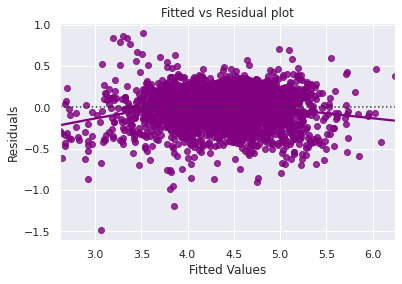

```python
# let's plot the fitted values vs residuals
sns.residplot(
    data=df_pred, x="Fitted Values", y="Residuals", color="purple", lowess=True
)
plt.xlabel("Fitted Values")
plt.ylabel("Residuals")
plt.title("Fitted vs Residual plot")
plt.show()
```

1. The scatter plot shows the distribution of residuals (errors) vs fitted values (predicted values).
2. If there exist any pattern in this plot, we consider it as signs of non-linearity in the data and a pattern means that the model doesn't capture non-linear effects.
3. **We see no pattern in the plot above. Hence, the assumptions of linearity and independence are satisfied.**

# **TEST FOR NORMALITY**

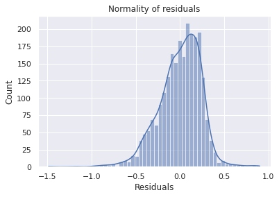

```python
sns.histplot(data=df_pred, x="Residuals", kde=True)
plt.title("Normality of residuals")
plt.show()
```

1. The histogram of residuals does have a bell shape.
2. Let's check the Q-Q plot.

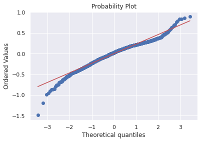

```python
import pylab
import scipy.stats as stats

stats.probplot(df_pred["Residuals"], dist="norm", plot=pylab)
plt.show()
```

1. The residuals more or less follow a straight line except for the tails.
2. Let's check the results of the Shapiro-Wilk test.

```python
stats.shapiro(df_pred["Residuals"])
```

```
ShapiroResult(statistic=0.9724023342132568, pvalue=3.463951697107566e-21)
```

1. Since p-value < 0.05, the residuals are not normal as per the Shapiro-Wilk test.
2. Strictly speaking, the residuals are not normal.
3. However, as an approximation, we can accept this distribution as close to being normal.
4. **So, the assumption is satisfied.**

# **Test for Homodescasticity**

The residual vs fitted values plot can be looked at to check for homoscedasticity. In the case of heteroscedasticity, the residuals can form an arrow shape or any other non-symmetrical shape.The goldfeldquandt test can also be used. If we get a p-value > 0.05 we can say that the residuals are homoscedastic. Otherwise, they are heteroscedastic.

**Null hypothesis: Residuals are homoscedastic**

**Alternate hypothesis: Residuals have heteroscedasticity**

```python
# imnporting the necessary packages for running homoscedastic test and deriving the p value
import statsmodels.stats.api as sms
from statsmodels.compat import lzip

name = ["F statistic", "p-value"]
test = sms.het_goldfeldquandt(df_pred["Residuals"], x_train3)
lzip(name, test)
```

```
[('F statistic', 1.0554902509992028), ('p-value', 0.17520491832996798)]
```

**Since p-value > 0.05, we can say that the residuals are homoscedastic. So, this assumption is satisfied.**

# **Predictions on test data**

Now that we have checked all the assumptions of linear regression and they are satisfied, let's go ahead with prediction.

```python
pred = olsmod2.predict(x_test3)

df_pred_test = pd.DataFrame({"Actual": y_test, "Predicted": pred})
df_pred_test.sample(10, random_state=1)
```

|  | Actual | Predicted |
| --- | --- | --- |
| 1995 | 4.566741 | 4.370046 |
| 2341 | 3.696103 | 3.954403 |
| 1913 | 3.592093 | 3.760742 |
| 688 | 4.306495 | 4.099280 |
| 650 | 4.522115 | 5.117977 |
| 2291 | 4.259294 | 4.392088 |
| 40 | 4.997685 | 5.404365 |
| 1884 | 3.875359 | 4.103732 |
| 2538 | 4.206631 | 4.044604 |
| 45 | 5.380450 | 5.301336 |

**We can observe here that our model has returned pretty good prediction results, and the actual and predicted values are comparable**

## Final Model

```python
x_train_final = x_train3.copy()
x_test_final = x_test3.copy()
```

```python
olsmodel_final = sm.OLS(y_train, x_train_final).fit()
print(olsmodel_final.summary())
```

```
                              OLS Regression Results
=================================================================================
Dep. Variable:     normalized_used_price   R-squared:                       0.839
Model:                               OLS   Adj. R-squared:                  0.839
Method:                    Least Squares   F-statistic:                     1142.
Date:                   Wed, 10 Aug 2022   Prob (F-statistic):               0.00
Time:                           01:23:33   Log-Likelihood:                 81.071
No. Observations:                   2417   AIC:                            -138.1
Df Residuals:                       2405   BIC:                            -68.66
Df Model:                             11
Covariance Type:               nonrobust
========================================================================================
                           coef    std err          t      P>|t|      [0.025      0.975]
----------------------------------------------------------------------------------------
const                    1.2119      0.046     26.274      0.000       1.121       1.302
screen_size              0.0433      0.002     28.306      0.000       0.040       0.046
main_camera_mp           0.0189      0.001     13.938      0.000       0.016       0.022
selfie_camera_mp         0.0131      0.001     12.372      0.000       0.011       0.015
ram                      0.0172      0.004      3.914      0.000       0.009       0.026
days_used             6.226e-05   3.03e-05      2.052      0.040    2.75e-06       0.000
normalized_new_price     0.4282      0.011     39.576      0.000       0.407       0.449
years_since_release     -0.0181      0.004     -4.184      0.000      -0.027      -0.010
brand_name_Lenovo        0.0489      0.022      2.261      0.024       0.006       0.091
brand_name_Nokia         0.0733      0.030      2.458      0.014       0.015       0.132
brand_name_Xiaomi        0.0852      0.026      3.320      0.001       0.035       0.135
4g_yes                   0.0369      0.015      2.456      0.014       0.007       0.066
==============================================================================
Omnibus:                      217.147   Durbin-Watson:                   1.916
Prob(Omnibus):                  0.000   Jarque-Bera (JB):              403.764
Skew:                          -0.610   Prob(JB):                     2.11e-88
Kurtosis:                       4.588   Cond. No.                     7.13e+03
==============================================================================

Warnings:
[1] Standard Errors assume that the covariance matrix of the errors is correctly specified.
[2] The condition number is large, 7.13e+03. This might indicate that there are
strong multicollinearity or other numerical problems.
```

```python
print("Training Performance\n")
olsmodel_final_train_perf = model_performance_regression(
    olsmodel_final, x_train_final, y_train
)
olsmodel_final_train_perf
```

```
Training Performance
```

|  | RMSE | MAE | R-squared | Adj. R-squared | MAPE |
| --- | --- | --- | --- | --- | --- |
| 0 | 0.233989 | 0.183177 | 0.839296 | 0.838494 | 4.392265 |

```python
print("Test Performance\n")
olsmodel_final_test_perf = model_performance_regression(
    olsmodel_final, x_test_final, y_test
)
olsmodel_final_test_perf
```

```
Test Performance
```

|  | RMSE | MAE | R-squared | Adj. R-squared | MAPE |
| --- | --- | --- | --- | --- | --- |
| 0 | 0.238554 | 0.185 | 0.84222 | 0.840371 | 4.500963 |

- The model is able to explain ~84% of the variation in the data
- The train and test RMSE and MAE are low and comparable. So, our model is not suffering from overfitting
- The MAPE on the test set suggests we can predict within 4.5% of the used prices
- Hence, we can conclude the model *olsmodel_final* is good for prediction as well as inference purposes